# Exploration_Ford_GoBike_System_Data

# (Ford GoBike System Dataset Exploration) ## by (Muhammad Salah Soliman) ## Preliminary Wrangling > This document explores a dataset containing start stations, end stations and user info for approximately 183,412 Bike Trips.

```python
# import all packages and set plots to be embedded inline
import numpy as np
import pandas as pd
import matplotlib.pyplot as plt
import seaborn as sb

%matplotlib inline
```

> Load in your dataset and describe its properties through the questions below. Try and motivate your exploration goals through this section.

```python
df = pd.read_csv('201902_fordgobike_tripdata.csv')
```

```python
df.shape
```

```
(183412, 16)
```

```python
df.info()
```

```
<class 'pandas.core.frame.DataFrame'>
RangeIndex: 183412 entries, 0 to 183411
Data columns (total 16 columns):
 #   Column                   Non-Null Count   Dtype
---  ------                   --------------   -----
 0   duration_sec             183412 non-null  int64
 1   start_time               183412 non-null  object
 2   end_time                 183412 non-null  object
 3   start_station_id         183215 non-null  float64
 4   start_station_name       183215 non-null  object
 5   start_station_latitude   183412 non-null  float64
 6   start_station_longitude  183412 non-null  float64
 7   end_station_id           183215 non-null  float64
 8   end_station_name         183215 non-null  object
 9   end_station_latitude     183412 non-null  float64
 10  end_station_longitude    183412 non-null  float64
 11  bike_id                  183412 non-null  int64
 12  user_type                183412 non-null  object
 13  member_birth_year        175147 non-null  float64
 14  member_gender            175147 non-null  object
 15  bike_share_for_all_trip  183412 non-null  object
dtypes: float64(7), int64(2), object(7)
memory usage: 22.4+ MB
```

```python
df.head()
```

|  | duration_sec | start_time | end_time | start_station_id | start_station_name | start_station_latitude | start_station_longitude | end_station_id | end_station_name | end_station_latitude | end_station_longitude | bike_id | user_type | member_birth_year | member_gender | bike_share_for_all_trip |
| --- | --- | --- | --- | --- | --- | --- | --- | --- | --- | --- | --- | --- | --- | --- | --- | --- |
| 0 | 52185 | 2019-02-28 17:32:10.1450 | 2019-03-01 08:01:55.9750 | 21.0 | Montgomery St BART Station (Market St at 2nd St) | 37.789625 | -122.400811 | 13.0 | Commercial St at Montgomery St | 37.794231 | -122.402923 | 4902 | Customer | 1984.0 | Male | No |
| 1 | 42521 | 2019-02-28 18:53:21.7890 | 2019-03-01 06:42:03.0560 | 23.0 | The Embarcadero at Steuart St | 37.791464 | -122.391034 | 81.0 | Berry St at 4th St | 37.775880 | -122.393170 | 2535 | Customer | NaN | NaN | No |
| 2 | 61854 | 2019-02-28 12:13:13.2180 | 2019-03-01 05:24:08.1460 | 86.0 | Market St at Dolores St | 37.769305 | -122.426826 | 3.0 | Powell St BART Station (Market St at 4th St) | 37.786375 | -122.404904 | 5905 | Customer | 1972.0 | Male | No |
| 3 | 36490 | 2019-02-28 17:54:26.0100 | 2019-03-01 04:02:36.8420 | 375.0 | Grove St at Masonic Ave | 37.774836 | -122.446546 | 70.0 | Central Ave at Fell St | 37.773311 | -122.444293 | 6638 | Subscriber | 1989.0 | Other | No |
| 4 | 1585 | 2019-02-28 23:54:18.5490 | 2019-03-01 00:20:44.0740 | 7.0 | Frank H Ogawa Plaza | 37.804562 | -122.271738 | 222.0 | 10th Ave at E 15th St | 37.792714 | -122.248780 | 4898 | Subscriber | 1974.0 | Male | Yes |

```python
df.tail()
```

|  | duration_sec | start_time | end_time | start_station_id | start_station_name | start_station_latitude | start_station_longitude | end_station_id | end_station_name | end_station_latitude | end_station_longitude | bike_id | user_type | member_birth_year | member_gender | bike_share_for_all_trip |
| --- | --- | --- | --- | --- | --- | --- | --- | --- | --- | --- | --- | --- | --- | --- | --- | --- |
| 183407 | 480 | 2019-02-01 00:04:49.7240 | 2019-02-01 00:12:50.0340 | 27.0 | Beale St at Harrison St | 37.788059 | -122.391865 | 324.0 | Union Square (Powell St at Post St) | 37.788300 | -122.408531 | 4832 | Subscriber | 1996.0 | Male | No |
| 183408 | 313 | 2019-02-01 00:05:34.7440 | 2019-02-01 00:10:48.5020 | 21.0 | Montgomery St BART Station (Market St at 2nd St) | 37.789625 | -122.400811 | 66.0 | 3rd St at Townsend St | 37.778742 | -122.392741 | 4960 | Subscriber | 1984.0 | Male | No |
| 183409 | 141 | 2019-02-01 00:06:05.5490 | 2019-02-01 00:08:27.2200 | 278.0 | The Alameda at Bush St | 37.331932 | -121.904888 | 277.0 | Morrison Ave at Julian St | 37.333658 | -121.908586 | 3824 | Subscriber | 1990.0 | Male | Yes |
| 183410 | 139 | 2019-02-01 00:05:34.3600 | 2019-02-01 00:07:54.2870 | 220.0 | San Pablo Ave at MLK Jr Way | 37.811351 | -122.273422 | 216.0 | San Pablo Ave at 27th St | 37.817827 | -122.275698 | 5095 | Subscriber | 1988.0 | Male | No |
| 183411 | 271 | 2019-02-01 00:00:20.6360 | 2019-02-01 00:04:52.0580 | 24.0 | Spear St at Folsom St | 37.789677 | -122.390428 | 37.0 | 2nd St at Folsom St | 37.785000 | -122.395936 | 1057 | Subscriber | 1989.0 | Male | No |

```python
df.nunique()
```

```
duration_sec                 4752
start_time                 183401
end_time                   183397
start_station_id              329
start_station_name            329
start_station_latitude        334
start_station_longitude       335
end_station_id                329
end_station_name              329
end_station_latitude          335
end_station_longitude         335
bike_id                      4646
user_type                       2
member_birth_year              75
member_gender                   3
bike_share_for_all_trip         2
dtype: int64
```

```python
df.duration_sec.value_counts()
```

```
272      311
324      292
323      291
306      291
305      290
        ...
4820       1
2725       1
10707      1
59851      1
52185      1
Name: duration_sec, Length: 4752, dtype: int64
```

```python
df.duration_sec.mean()
```

```
726.078435434977
```

```python
df.start_station_id.value_counts()
```

```
58.0     3904
67.0     3544
81.0     3052
21.0     2895
3.0      2760
         ...
301.0       9
51.0        7
300.0       4
224.0       4
344.0       2
Name: start_station_id, Length: 329, dtype: int64
```

```python
df.start_station_name.value_counts()
```

```
Market St at 10th St                                         3904
San Francisco Caltrain Station 2  (Townsend St at 4th St)    3544
Berry St at 4th St                                           3052
Montgomery St BART Station (Market St at 2nd St)             2895
Powell St BART Station (Market St at 4th St)                 2760
                                                             ...
Willow St at Vine St                                            9
Parker Ave at McAllister St                                     7
Palm St at Willow St                                            4
21st Ave at International Blvd                                  4
16th St Depot                                                   2
Name: start_station_name, Length: 329, dtype: int64
```

```python
df.start_station_latitude.value_counts()
```

```
37.776619    3904
37.776639    3544
37.775880    3052
37.789625    2895
37.786375    2760
             ...
37.776101       7
37.317298       4
37.784855       4
37.766349       2
37.380000       1
Name: start_station_latitude, Length: 334, dtype: int64
```

```python
df.start_station_longitude.value_counts()
```

```
-122.417385    3904
-122.395526    3544
-122.393170    3052
-122.400811    2895
-122.404904    2760
               ...
-122.453093       7
-121.884995       4
-122.239305       4
-122.396292       2
-121.980000       1
Name: start_station_longitude, Length: 335, dtype: int64
```

```python
df.end_station_id.value_counts()
```

```
67.0     4857
58.0     3973
21.0     3647
15.0     3368
3.0      2997
         ...
51.0        9
300.0       7
224.0       6
344.0       6
301.0       5
Name: end_station_id, Length: 329, dtype: int64
```

```python
df.end_station_name.value_counts()
```

```
San Francisco Caltrain Station 2  (Townsend St at 4th St)    4857
Market St at 10th St                                         3973
Montgomery St BART Station (Market St at 2nd St)             3647
San Francisco Ferry Building (Harry Bridges Plaza)           3368
Powell St BART Station (Market St at 4th St)                 2997
                                                             ...
Parker Ave at McAllister St                                     9
Palm St at Willow St                                            7
16th St Depot                                                   6
21st Ave at International Blvd                                  6
Willow St at Vine St                                            5
Name: end_station_name, Length: 329, dtype: int64
```

```python
df.start_station_latitude.value_counts()
```

```
37.776619    3904
37.776639    3544
37.775880    3052
37.789625    2895
37.786375    2760
             ...
37.776101       7
37.317298       4
37.784855       4
37.766349       2
37.380000       1
Name: start_station_latitude, Length: 334, dtype: int64
```

```python
df.end_station_longitude.value_counts()
```

```
-122.395526    4857
-122.417385    3973
-122.400811    3647
-122.394203    3368
-122.404904    2997
               ...
-121.884995       7
-122.239305       6
-122.396292       6
-121.883172       5
-121.980000       2
Name: end_station_longitude, Length: 335, dtype: int64
```

```python
df.bike_id.value_counts()
```

```
4794    191
4814    176
4422    174
5014    174
5175    173
       ...
2306      1
1930      1
776       1
540       1
2148      1
Name: bike_id, Length: 4646, dtype: int64
```

```python
df.user_type.value_counts()
```

```
Subscriber    163544
Customer       19868
Name: user_type, dtype: int64
```

```python
df.member_birth_year.value_counts()
```

```
1988.0    10236
1993.0     9325
1989.0     8972
1990.0     8658
1991.0     8498
          ...
1928.0        1
1927.0        1
1910.0        1
1930.0        1
1878.0        1
Name: member_birth_year, Length: 75, dtype: int64
```

```python
df.member_birth_year.describe()
```

```
count    175147.000000
mean       1984.806437
std          10.116689
min        1878.000000
25%        1980.000000
50%        1987.000000
75%        1992.000000
max        2001.000000
Name: member_birth_year, dtype: float64
```

```python
df.member_gender.value_counts()
```

```
Male      130651
Female     40844
Other       3652
Name: member_gender, dtype: int64
```

```python
df.bike_share_for_all_trip.value_counts()
```

```
No     166053
Yes     17359
Name: bike_share_for_all_trip, dtype: int64
```

### What is the structure of your dataset?

> There are 183,412 Bike Trip data in the dataset with details in the columns for:

1- (Duration - start and end time

2- Start and End station and their location in latitude and longitude

3- Bike ID

4- User Type ( Suscriber or one-time Customer)

5- Member Birthyear

6- Member Gender

7- Bike Share for all ( Indicates whether the user is a member of a program for low-income residents)

### What is/are the main feature(s) of interest in your dataset?

> I'm most interested in figuring out what features are best for predicting the ride duration in the dataset.

### What features in the dataset do you think will help support your investigation into your feature(s) of interest?

> I think that the strongest effect will be the age of the user in addition to the user type, i am personally interested to check if the gender of the user also affects the bike duration

## Data Cleaning:

Will start by conducting a little data cleaning to make the data more "usable" with clear adjustments before the Visual Exploration through adjusting the following

1- Data Types:

a- start_time Old Dtype object Will Convert to Date_time

b- end_time Old Dtype object Will Convert to Date_time

c- start_station_id Old Dtype float64 Will Convert to Int

d- end_station_id Old Dtype float64 Will Convert to Int

e- member_birth_year Old Dtype float64 Will Convert to Int

2- Duration will create duration by minutes column I/O seconds

3- Gender: Will eliminate rows with incomplete data in gender and birthyear details the Other

3- Will create member age from member Birth year

4- Will Eliminate users exceeding 100 years of age as of 2019

6- Gender Will eliminate rows with "Other" listed in Gender

7- Eliminate Rows with no Start or End Stations

```python
df['start_time'] = pd.to_datetime(df['start_time'])
df['end_time'] = pd.to_datetime(df['end_time'])
```

```python
df['duration_min'] = df['duration_sec'] / 60
df = df.dropna()
df['age'] = 2019 - df['member_birth_year']
df = df[df.age < 100]
df = df[df.member_gender != "Other"]
```

```python
df['member_birth_year'] = df['member_birth_year'].astype(int)
df['end_station_id'] = df['end_station_id'].astype(int)
df['start_station_id'] = df['start_station_id'].astype(int)
```

Checking that cleaning was successful

```python
df.info()
```

```
<class 'pandas.core.frame.DataFrame'>
Int64Index: 171234 entries, 0 to 183411
Data columns (total 18 columns):
 #   Column                   Non-Null Count   Dtype
---  ------                   --------------   -----
 0   duration_sec             171234 non-null  int64
 1   start_time               171234 non-null  datetime64[ns]
 2   end_time                 171234 non-null  datetime64[ns]
 3   start_station_id         171234 non-null  int32
 4   start_station_name       171234 non-null  object
 5   start_station_latitude   171234 non-null  float64
 6   start_station_longitude  171234 non-null  float64
 7   end_station_id           171234 non-null  int32
 8   end_station_name         171234 non-null  object
 9   end_station_latitude     171234 non-null  float64
 10  end_station_longitude    171234 non-null  float64
 11  bike_id                  171234 non-null  int64
 12  user_type                171234 non-null  object
 13  member_birth_year        171234 non-null  int32
 14  member_gender            171234 non-null  object
 15  bike_share_for_all_trip  171234 non-null  object
 16  duration_min             171234 non-null  float64
 17  age                      171234 non-null  float64
dtypes: datetime64[ns](2), float64(6), int32(3), int64(2), object(5)
memory usage: 22.9+ MB
```

```python
df.age.describe()
```

```
count    171234.000000
mean         34.125507
std           9.969689
min          18.000000
25%          27.000000
50%          32.000000
75%          39.000000
max          99.000000
Name: age, dtype: float64
```

```python
df.member_gender.value_counts()
```

```
Male      130443
Female     40791
Name: member_gender, dtype: int64
```

```python
df.bike_share_for_all_trip.value_counts()
```

```
No     154563
Yes     16671
Name: bike_share_for_all_trip, dtype: int64
```

```python
df.duration_min.describe()
```

```
count    171234.000000
mean         11.629593
std          26.292516
min           1.016667
25%           5.370833
50%           8.483333
75%          13.116667
max        1409.133333
Name: duration_min, dtype: float64
```

## Univariate Exploration

> In this section, investigate distributions of individual variables. If you see unusual points or outliers, take a deeper look to clean things up and prepare yourself to look at relationships between variables.

I'll start by looking at the distribution of the main variable of interest: Duration.

> Make sure that, after every plot or related series of plots, that you include a Markdown cell with comments about what you observed, and what you plan on investigating next.

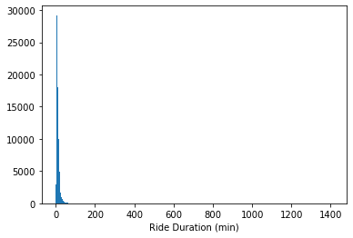

```python
binsize = 2
bins = np.arange (0, df.duration_min.max()+binsize, binsize)
plt.hist(data = df, x = 'duration_min', bins = bins)
plt.xlabel('Ride Duration (min)')
plt.show;
```

Seems that there is outlier(s) in the data affecting the histogram

```python
df.duration_min.describe()
```

```
count    171234.000000
mean         11.629593
std          26.292516
min           1.016667
25%           5.370833
50%           8.483333
75%          13.116667
max        1409.133333
Name: duration_min, dtype: float64
```

```python
df[df.duration_min < 100].duration_min.describe()
```

```
count    170573.000000
mean         10.534118
std           8.410316
min           1.016667
25%           5.366667
50%           8.466667
75%          13.050000
max          99.766667
Name: duration_min, dtype: float64
```

Will exclude rows with outliers in duration of 100 minutes or above from the data

```python
df = df[df.duration_min < 100]
```

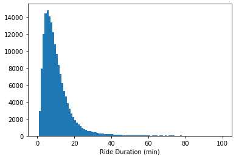

```python
binsize = 1
bins = np.arange (0, df.duration_min.max()+binsize, binsize)
plt.hist(data = df, x = 'duration_min', bins = bins)
plt.xlabel('Ride Duration (min)')
plt.show;
```

It is clear that the ride duration distribution has a right skew with the bulk of the data between 0 and 20

# Age

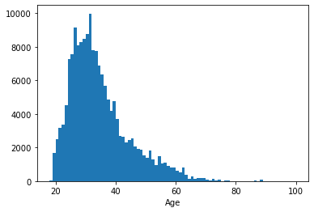

```
count    170573.000000
mean         34.120740
std           9.968214
min          18.000000
25%          27.000000
50%          32.000000
75%          39.000000
max          99.000000
Name: age, dtype: float64
```

```python
binsize = 1
bins = np.arange(18, 101, binsize)
plt.hist(data = df, x = 'age', bins = bins)
plt.xlabel('Age')
plt.show()
df.age.describe()
```

It is clear that the bulk of the users are between 20 and 40 Years of Age With the Minimum age of 18 and the distribution in right skewed

[figure not shown]

```python
df.hist(figsize = (15,15));
```

## Gender

```
Male      0.762037
Female    0.237963
Name: member_gender, dtype: float64
```

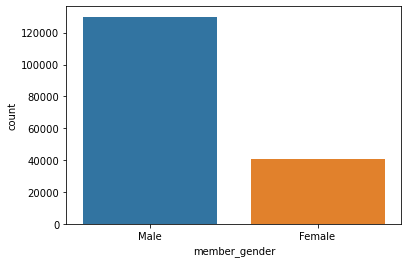

```python
sb.countplot(data=df, x='member_gender');
df.member_gender.value_counts(normalize = True)
```

It is clear from the chart above that most of the users are males with over 76.2% of rentals were done by males

### Discuss the distribution(s) of your variable(s) of interest. Were there any unusual points? Did you need to perform any transformations?

> Yes such as the outliers in Duration and Age

### Of the features you investigated, were there any unusual distributions? Did you perform any operations on the data to tidy, adjust, or change the form of the data? If so, why did you do this?

> Yes i Did and explained above

## Bivariate Exploration

> In this section, investigate relationships between pairs of variables in your data. Make sure the variables that you cover here have been introduced in some fashion in the previous section (univariate exploration).

1st: Relationship between duration and Age

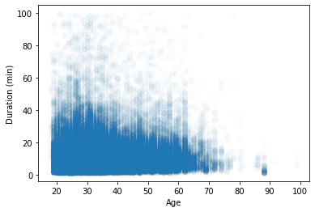

```python
plt.scatter(data = df, x = 'age', y = 'duration_min', alpha=1/50);
plt.xlabel('Age')
plt.ylabel('Duration (min)');
```

2nd: Relationship between duration and Gender

```
(-6.257652489196026, 106.7243191558627)
```

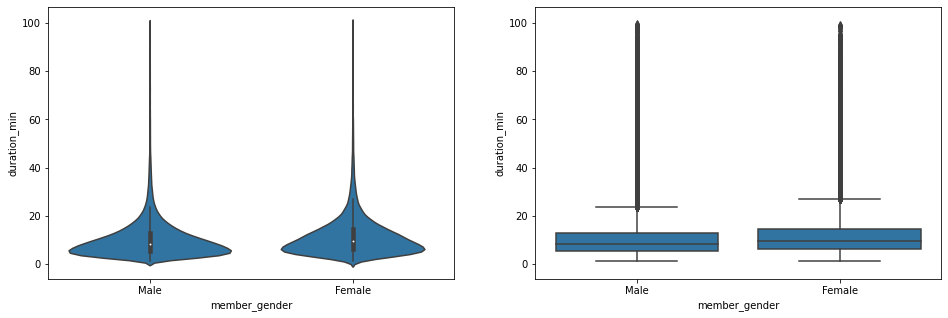

```python
plt.figure(figsize = [16, 5])
base_color = sb.color_palette()[0]

# LEFT plot: violin plot
plt.subplot(1, 2, 1)
#Let's return the axes object
ax1 = sb.violinplot(data=df, x='member_gender', y='duration_min', color=base_color, innner='quartile');

# RIGHT plot: box plot
plt.subplot(1, 2, 2)
sb.boxplot(data=df, x='member_gender', y='duration_min', color=base_color);
plt.ylim(ax1.get_ylim()) # set y-axis limits to be same as left plot
```

It seems that Female ride duration is longer on average than the mail duration

### Did you observe any interesting relationships between the other features (not the main feature(s) of interest)?

> Didn't check

## Multivariate Exploration

> Create plots of three or more variables to investigate your data even further. Make sure that your investigations are justified, and follow from your work in the previous sections.

I am going to check the relationship between age, duration and Gender

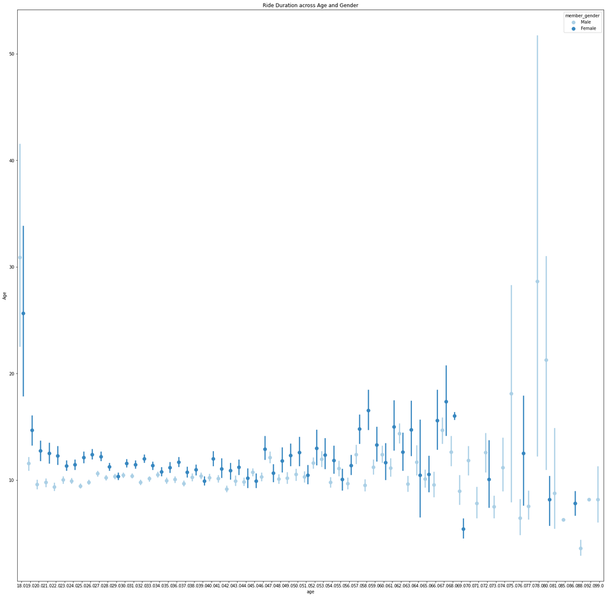

```python
fig = plt.figure(figsize = [25,25])
ax = sb.pointplot(data = df, x = 'age', y = 'duration_min', hue = 'member_gender',
           palette = 'Blues', linestyles = '', dodge = 0.4)
plt.title('Ride Duration across Age and Gender')
plt.ylabel('Duration (min)')
plt.ylabel('Age')

plt.show();
```

### Were there any interesting or surprising interactions between features?

> Yes the above relationship was quite surprising to me